# Geospatial Risk Prediction

Shujing Yi

10/19/2022

# Introduction

Even though there is prevalent bias in predictive policing models, many cities still utilize these algorithms to make decisions regarding allocating resources and funding. This project breaks down the process of building and judging one such algorithm. In this project, I use past 2017 crime reports from the city of Chicago to predict future locations of assaults.

Assault is generally defined as an intentional act that puts another person in reasonable apprehension of imminent harmful or offensive contact. Crimes such as assault are influenced by several sociopolitical and environmental factors that may not be related to locations. Besides, not every crime gets reported. These types of models could possibly assume characteristics of a person make them more likely to commit a crime than another, which leads to bias prediction.

We need to be aware of the bias of our data sources and our own bias as we build and use such models.

# Setup

First, I import the necessary libraries and themes and define the functions.

# Data Wrangling

## Assaults Distribution in Chicago

Next, I import geographies for police units, 2017 Chicago crime data, and a boundary of the city in order to plot the locations of reports of assaults in 2017.

```r
policeDistricts <-
  st_read("https://data.cityofchicago.org/api/geospatial/fthy-xz3r?method=export&format=GeoJSON") %>%
  st_transform('ESRI:102271') %>%
  dplyr::select(District = dist_num)

policeBeats <-
  st_read("https://data.cityofchicago.org/api/geospatial/aerh-rz74?method=export&format=GeoJSON") %>%
  st_transform('ESRI:102271') %>%
  dplyr::select(District = beat_num)

bothPoliceUnits <- rbind(mutate(policeDistricts, Legend = "Police Districts"),
                         mutate(policeBeats, Legend = "Police Beats"))

assault <-
  read.socrata("https://data.cityofchicago.org/Public-Safety/Crimes-2017/d62x-nvdr") %>%
    filter(Primary.Type == "ASSAULT" & Description == "SIMPLE") %>%
    mutate(x = gsub("[()]", "", Location)) %>%
    separate(x,into= c("Y","X"), sep=",") %>%
    mutate(X = as.numeric(X),Y = as.numeric(Y)) %>%
    na.omit() %>%
    st_as_sf(coords = c("X", "Y"), crs = 4326, agr = "constant")%>%
    st_transform('ESRI:102271') %>%
    distinct()

chicagoBoundary <-
  st_read(file.path(root.dir,"/Chapter5/chicagoBoundary.geojson")) %>%
  st_transform('ESRI:102271')
```

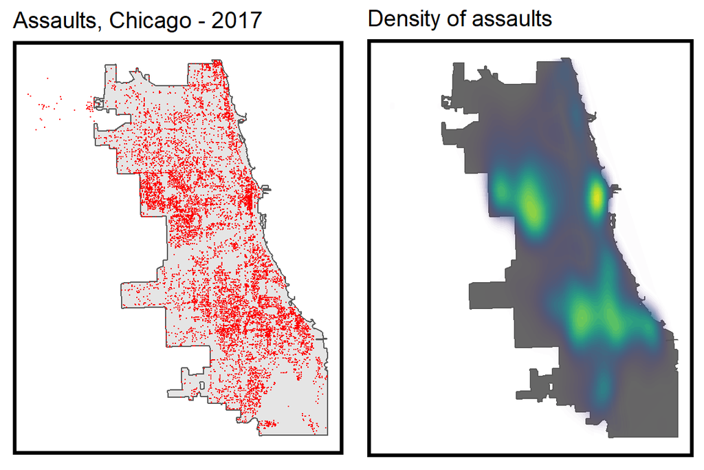

```r
# uses grid.arrange to organize independent plots
grid.arrange(ncol=2,
ggplot() +
  geom_sf(data = chicagoBoundary) +
  geom_sf(data = assault, colour="red", size=0.1, show.legend = "point") +
  labs(title= "Assaults, Chicago - 2017") +
  mapTheme(title_size = 14),

ggplot() +
  geom_sf(data = chicagoBoundary, fill = "grey40") +
  stat_density2d(data = data.frame(st_coordinates(assault)),
                 aes(X, Y, fill = ..level.., alpha = ..level..),
                 size = 0.01, bins = 40, geom = 'polygon') +
  scale_fill_viridis() +
  scale_alpha(range = c(0.00, 0.35), guide = FALSE) +
  labs(title = "Density of assaults") +
  mapTheme(title_size = 14) + theme(legend.position = "none"))
```

The maps show that there is some evident clustering of the crime location. However, it is important to note that the clusters are in areas of Chicago that are heavily policed for their reputation of being dangerous. Many assaults don’t get reported due to many social and environmental factors, such as fear of not being believed. Besides, if selective enforcement results from an officer’s preconceived or biased beliefs, then this ‘selection bias’ will be baked into the crime outcome. Selection bias may decrease the accuracy and generalizability of the model.

## Creating a fishnet grid

I create 500 by 500 fishnet grids and aggregate the total number of assaults to each grid cell by using the coordinates of the assault and finding which cell it falls within.

```r
fishnet <-
  st_make_grid(chicagoBoundary,
               cellsize = 500,
               square = TRUE) %>%
  .[chicagoBoundary] %>%            # fast way to select intersecting polygons
  st_sf() %>%
  mutate(uniqueID = 1:n())
```

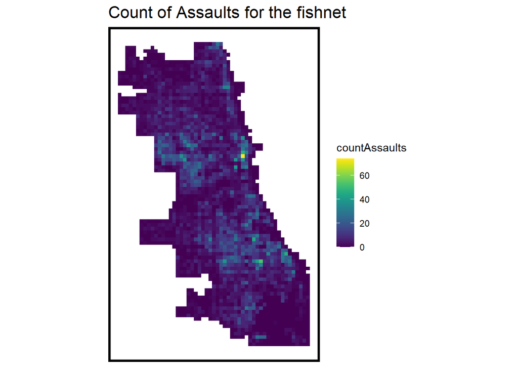

```r
## add a value of 1 to each crime, sum them with aggregate
crime_net <-
  dplyr::select(assault) %>%
  mutate(countAssaults = 1) %>%
  aggregate(., fishnet, sum) %>%
  mutate(countAssaults = replace_na(countAssaults, 0),
         uniqueID = 1:n(),
         cvID = sample(round(nrow(fishnet) / 24),
                       size=nrow(fishnet), replace = TRUE))

ggplot() +
  geom_sf(data = crime_net, aes(fill = countAssaults), color = NA) +
  scale_fill_viridis() +
  labs(title = "Count of Assaults for the fishnet") +
  mapTheme()
```

# Feature Engineering

In this section, I move on to modeling the risk factors that are the independent variables. I used the following variables: abandoned cars, abandoned buildings, street lights out, sanitation, graffiti, liquor retails, grocery stores, restaurants, and affordable rentals. The first five variables were taken from 311 calls and they likely have a reporting bias that one needs to be aware of. Also, some variables marginalize and make assumptions connecting to one or more communities which adds to the racial and systematic bias.

```r
## only pulling a single variable for our model to keep it simple
## using Socrata again
abandonCars <-
  read.socrata("https://data.cityofchicago.org/Service-Requests/311-Service-Requests-Abandoned-Vehicles/3c9v-pnva") %>%
    mutate(year = substr(creation_date,1,4)) %>% filter(year == "2017") %>%
    dplyr::select(Y = latitude, X = longitude) %>%
    na.omit() %>%
    st_as_sf(coords = c("X", "Y"), crs = 4326, agr = "constant") %>%
    st_transform(st_crs(fishnet)) %>%
    mutate(Legend = "Abandoned_Cars")

abandonBuildings <-
  read.socrata("https://data.cityofchicago.org/Service-Requests/311-Service-Requests-Vacant-and-Abandoned-Building/7nii-7srd") %>%
    mutate(year = substr(date_service_request_was_received,1,4)) %>%  filter(year == "2017") %>%
    dplyr::select(Y = latitude, X = longitude) %>%
    na.omit() %>%
    st_as_sf(coords = c("X", "Y"), crs = 4326, agr = "constant") %>%
    st_transform(st_crs(fishnet)) %>%
    mutate(Legend = "Abandoned_Buildings")

graffiti <-
  read.socrata("https://data.cityofchicago.org/Service-Requests/311-Service-Requests-Graffiti-Removal-Historical/hec5-y4x5") %>%
    mutate(year = substr(creation_date,1,4)) %>% filter(year == "2017") %>%
    filter(where_is_the_graffiti_located_ %in% c("Front", "Rear", "Side")) %>%
    dplyr::select(Y = latitude, X = longitude) %>%
    na.omit() %>%
    st_as_sf(coords = c("X", "Y"), crs = 4326, agr = "constant") %>%
    st_transform(st_crs(fishnet)) %>%
    mutate(Legend = "Graffiti")

streetLightsOut <-
  read.socrata("https://data.cityofchicago.org/Service-Requests/311-Service-Requests-Street-Lights-All-Out/zuxi-7xem") %>%
    mutate(year = substr(creation_date,1,4)) %>% filter(year == "2017") %>%
    dplyr::select(Y = latitude, X = longitude) %>%
    na.omit() %>%
    st_as_sf(coords = c("X", "Y"), crs = 4326, agr = "constant") %>%
    st_transform(st_crs(fishnet)) %>%
    mutate(Legend = "Street_Lights_Out")

sanitation <-
  read.socrata("https://data.cityofchicago.org/Service-Requests/311-Service-Requests-Sanitation-Code-Complaints-Hi/me59-5fac") %>%
    mutate(year = substr(creation_date,1,4)) %>% filter(year == "2017") %>%
    dplyr::select(Y = latitude, X = longitude) %>%
    na.omit() %>%
    st_as_sf(coords = c("X", "Y"), crs = 4326, agr = "constant") %>%
    st_transform(st_crs(fishnet)) %>%
    mutate(Legend = "Sanitation")

liquorRetail <-
  read.socrata("https://data.cityofchicago.org/resource/nrmj-3kcf.json") %>%
    filter(business_activity == "Retail Sales of Packaged Liquor") %>%
    dplyr::select(Y = latitude, X = longitude) %>%
    na.omit() %>%
    st_as_sf(coords = c("X", "Y"), crs = 4326, agr = "constant") %>%
    st_transform(st_crs(fishnet)) %>%
    mutate(Legend = "Liquor_Retail")

grocery <-
  read.socrata("https://data.cityofchicago.org/Community-Economic-Development/Grocery-Stores-2013/53t8-wyrc") %>%
    dplyr::select(Y = latitude, X = longitude) %>%
    na.omit() %>%
    st_as_sf(coords = c("X", "Y"), crs = 4326, agr = "constant") %>%
    st_transform(st_crs(fishnet)) %>%
    mutate(Legend = "Grocery")

restaurant <-
  read.socrata("https://data.cityofchicago.org/Health-Human-Services/Food-Inspections-1-1-2010-6-30-2018/puke-h9vk") %>%
    mutate(year = substr(Inspection.Date,1,4)) %>%  filter(year == "2017") %>%
    filter(Results %in% c("Pass w/ Conditions", "Pass", "Fail")) %>%
    distinct(License.., .keep_all = TRUE) %>%
    dplyr::select(Y = Latitude, X = Longitude) %>%
    na.omit() %>%
    st_as_sf(coords = c("X", "Y"), crs = 4326, agr = "constant") %>%
    st_transform(st_crs(fishnet)) %>%
    mutate(Legend = "Restaurants")

affordableRental <-
  read.socrata("https://data.cityofchicago.org/resource/s6ha-ppgi.json") %>%
    dplyr::select(Y = latitude, X = longitude) %>%
    na.omit() %>%
    st_as_sf(coords = c("X", "Y"), crs = 4326, agr = "constant") %>%
    st_transform(st_crs(fishnet)) %>%
    mutate(Legend = "Affordable_Rental_Housing")


## Neighborhoods to use in LOOCV in a bit
neighborhoods <-
  st_read("https://raw.githubusercontent.com/blackmad/neighborhoods/master/chicago.geojson") %>%
  st_transform(st_crs(fishnet))
```

### Count of risk factors by grid cell

Now we bind all the variables and add them to the fishnet to calculate the count within each grid cell.

```r
vars_net <-  rbind(abandonCars,streetLightsOut,abandonBuildings,
        liquorRetail, graffiti, sanitation, grocery, restaurant,affordableRental )  %>%
  st_join(fishnet, join=st_within) %>%
  st_drop_geometry() %>%
  group_by(uniqueID, Legend) %>%
  summarize(count = n()) %>%
  left_join(fishnet, ., by = "uniqueID") %>%
  spread(Legend, count, fill=0) %>%
  dplyr::select(-`<NA>`) %>%
  ungroup()
```

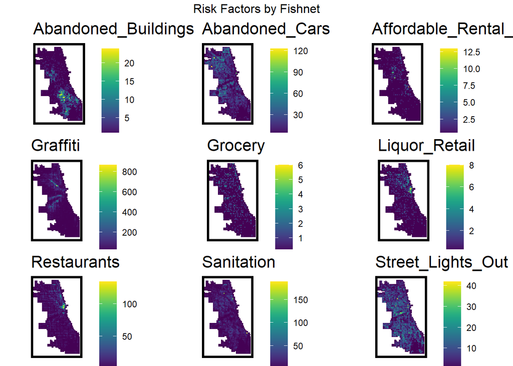

```r
vars_net.long <-
  gather(vars_net, Variable, value, -geometry, -uniqueID)

vars <- unique(vars_net.long$Variable)
mapList <- list()

for(i in vars){
  mapList[[i]] <-
    ggplot() +
      geom_sf(data = filter(vars_net.long, Variable == i), aes(fill=value), colour=NA) +
      scale_fill_viridis(name="") +
      labs(title=i) +
      mapTheme()}

do.call(grid.arrange,c(mapList, ncol=3, top="Risk Factors by Fishnet"))
```

## Nearest Neighbor Feature

```r
# convinience to reduce length of function names.
st_c    <- st_coordinates
st_coid <- st_centroid

## create NN from abandoned cars
vars_net <- vars_net %>%
    mutate(
      Abandoned_Cars.nn = nn_function(st_c(st_coid(vars_net)),
                                           st_c(abandonCars),3),
       Abandoned_Buildings.nn =
        nn_function(st_c(st_coid(vars_net)), st_c(abandonBuildings),3),
      Graffiti.nn =
        nn_function(st_c(st_coid(vars_net)), st_c(graffiti),3),
      Liquor_Retail.nn =
        nn_function(st_c(st_coid(vars_net)), st_c(liquorRetail),3),
      Street_Lights_Out.nn =
        nn_function(st_c(st_coid(vars_net)), st_c(streetLightsOut),3),
      Sanitation.nn =
        nn_function(st_c(st_coid(vars_net)), st_c(sanitation),3),
      grocery.nn =
        nn_function(st_c(st_coid(vars_net)), st_c(grocery),3),
      restaurant.nn =
        nn_function(st_c(st_coid(vars_net)), st_c(restaurant),3),
      affordableRental.nn =
        nn_function(st_c(st_coid(vars_net)), st_c(affordableRental),3),
        )
```

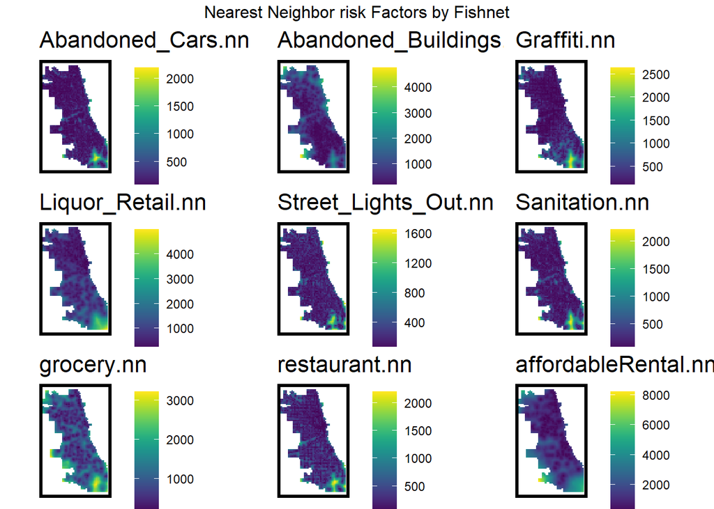

```r
## Visualize the NN feature
vars_net.long.nn <-
  dplyr::select(vars_net, ends_with(".nn")) %>%
    gather(Variable, value, -geometry)

vars <- unique(vars_net.long.nn$Variable)
mapList <- list()

for(i in vars){
  mapList[[i]] <-
ggplot() +
      geom_sf(data = filter(vars_net.long.nn,Variable == i), aes(fill=value), colour=NA) +
      scale_fill_viridis(name="") +
      labs(title=i) +
      mapTheme()}

do.call(grid.arrange,c(mapList, ncol = 3, top = "Nearest Neighbor risk Factors by Fishnet"))
```

## Measure distance to one point

It also may be reasonable to measure distance to a single point, like the centroid of the Loop - Chicago’s Central Business District.

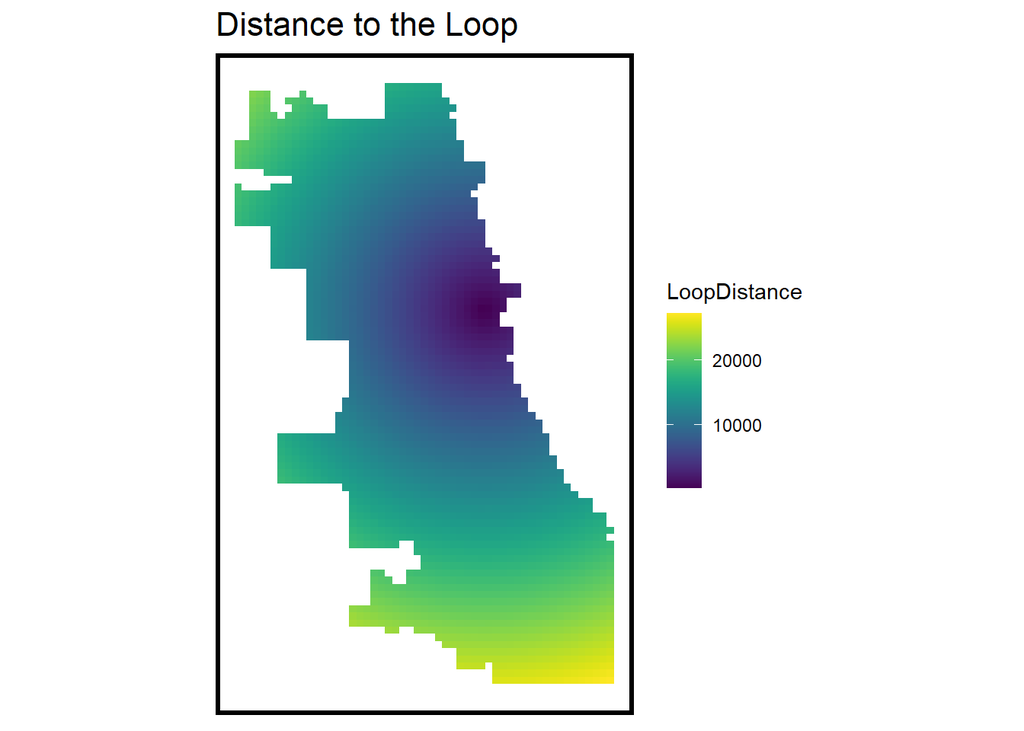

```r
loopPoint <-
  filter(neighborhoods, name == "Loop") %>%
  st_centroid()

vars_net$loopDistance =
  st_distance(st_centroid(vars_net),loopPoint) %>%
  as.numeric()

ggplot() +
      geom_sf(data = vars_net, aes(fill=loopDistance), colour=NA) +
      scale_fill_viridis(name="LoopDistance") +
      labs(title="Distance to the Loop") +
      mapTheme()
```

## Create the final_net

Next, the crime_net and vars_net layers are joined into one regression-ready, final_net.

```r
## important to drop the geometry from joining features
final_net <-
  left_join(crime_net, st_drop_geometry(vars_net), by="uniqueID")

final_net <-
  st_centroid(final_net) %>%
    st_join(dplyr::select(neighborhoods, name), by = "uniqueID") %>%
    st_join(dplyr::select(policeDistricts, District), by = "uniqueID") %>%
      st_drop_geometry() %>%
      left_join(dplyr::select(final_net, geometry, uniqueID)) %>%
      st_sf() %>%
  na.omit()
```

# Local Moran’s I

After understanding the spatial processes of selected risk factors, I explore the spatial process of the crime by calculating a statistic known as Local Moran’s I. The Local Moran’s I utilizes a spatial weights matrix to relate each grid cell in the fishnet with its neighbors.

```r
## generates warnings from PROJ issues
## {spdep} to make polygon to neighborhoods...
final_net.nb <- poly2nb(as_Spatial(final_net), queen=TRUE)
## ... and neighborhoods to list of weigths
final_net.weights <- nb2listw(final_net.nb, style="W", zero.policy=TRUE)
```

```r
## see ?localmoran
local_morans <- localmoran(final_net$countAssaults, final_net.weights, zero.policy=TRUE) %>%
  as.data.frame()

# join local Moran's I results to fishnet
final_net.localMorans <-
  cbind(local_morans, as.data.frame(final_net)) %>%
  st_sf() %>%
  dplyr::select(Assult_Count = countAssaults,
                Local_Morans_I = Ii,
                P_Value = `Pr(z != E(Ii))`) %>%
  mutate(Significant_Hotspots = ifelse(P_Value <= 0.001, 1, 0)) %>%
  gather(Variable, Value, -geometry)
```

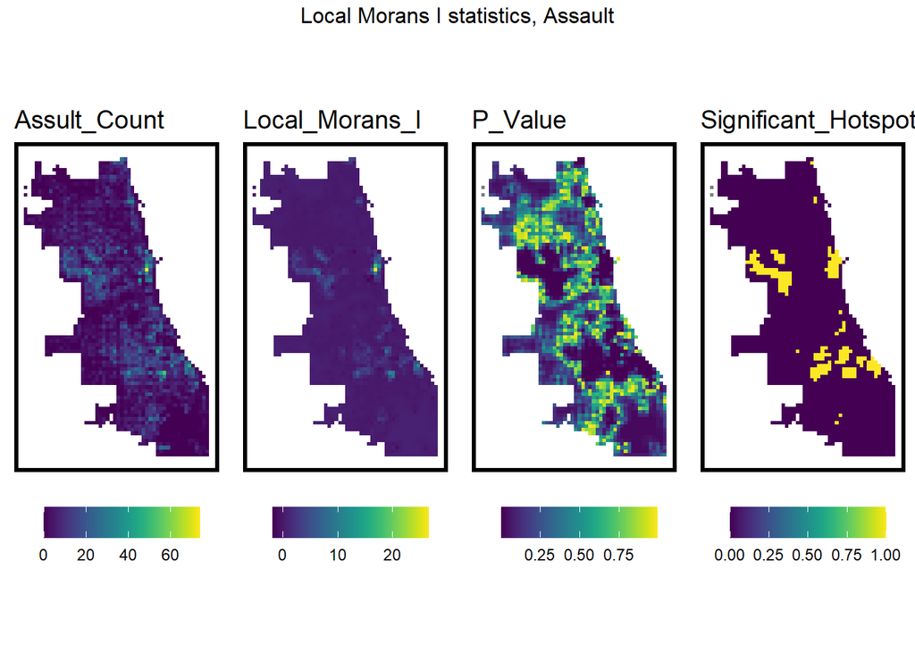

```r
## This is just for plotting
vars <- unique(final_net.localMorans$Variable)
varList <- list()

for(i in vars){
  varList[[i]] <-
    ggplot() +
      geom_sf(data = filter(final_net.localMorans, Variable == i),
              aes(fill = Value), colour=NA) +
      scale_fill_viridis(name="") +
      labs(title=i) +
      mapTheme(title_size = 14) + theme(legend.position="bottom")}

do.call(grid.arrange,c(varList, ncol = 4, top = "Local Morans I statistics, Assault"))
```

Together, these four maps indicate strong clustering at play with assaults in Chicago. This implies that our model must control this spatial process to be generalizable across hotspot and coldspot areas.

## Distance to Hot spot

Then I use the above identfied hotspots to assign a value to each grid cell based on its distance to a hotspot.

```r
# generates warning from NN
final_net <- final_net %>%
  mutate(Assualt.isSig =
           ifelse(local_morans[,5] <= 0.001, 1, 0)) %>%
  mutate(Assualt.isSig.dist =
           nn_function(st_c(st_coid(final_net)),
                       st_c(st_coid(filter(final_net,
                                           Assualt.isSig == 1))),
                       k = 1))

## What does k = 1 represent?
```

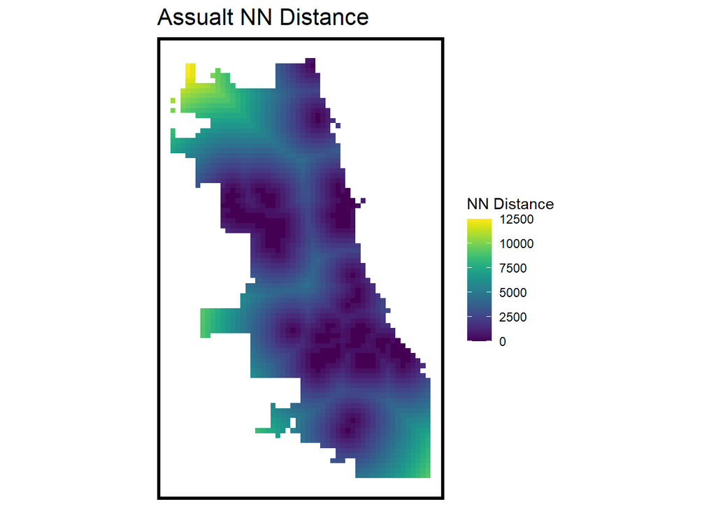

```r
ggplot() +
      geom_sf(data = final_net, aes(fill=Assualt.isSig.dist), colour=NA) +
      scale_fill_viridis(name="NN Distance") +
      labs(title="Assualt NN Distance") +
      mapTheme()
```

# Correlation Tests

We can observe the relationships between risk factors and assaults with correlation tests. The r values help to determine how strong the relationship is with the dependent variable. However, we also needed to consider that in multivariate regression, their relationships with each other will affect the risk factors correlations. Therefore, we could not select the features only based on this correlation test, but we also had to observe how they would affect the MAE of our regression model.

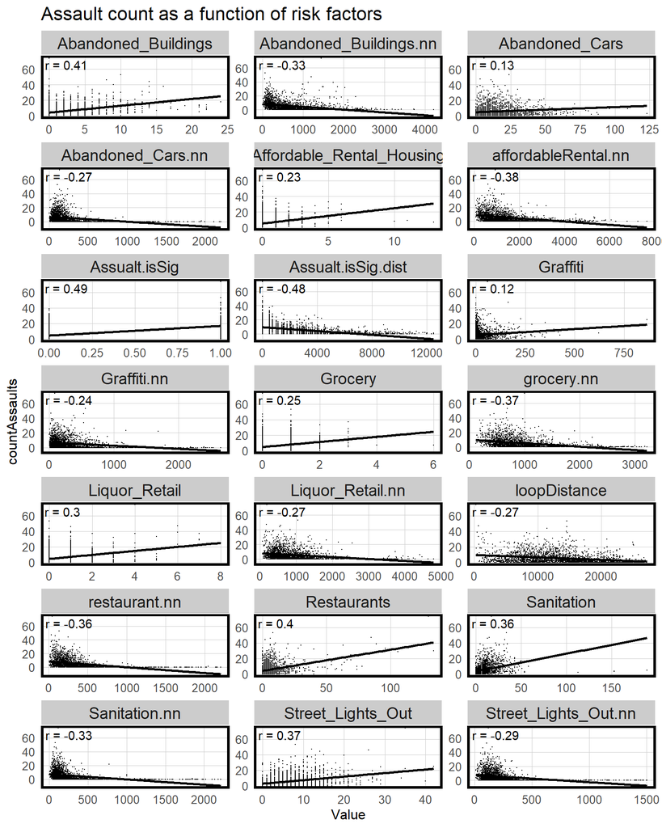

```r
correlation.long <-
  st_drop_geometry(final_net) %>%
    dplyr::select(-uniqueID, -cvID, -name, -District) %>%
    gather(Variable, Value, -countAssaults)

correlation.cor <-
  correlation.long %>%
    group_by(Variable) %>%
    summarize(correlation = cor(Value, countAssaults, use = "complete.obs"))

ggplot(correlation.long, aes(Value, countAssaults)) +
  geom_point(size = 0.1) +
  geom_text(data = correlation.cor, aes(label = paste("r =", round(correlation, 2))),
            x=-Inf, y=Inf, vjust = 1.5, hjust = -.1) +
  geom_smooth(method = "lm", se = FALSE, colour = "black") +
  facet_wrap(~Variable, ncol = 3, scales = "free") +
  labs(title = "Assault count as a function of risk factors") +
  plotTheme()
```

# Poisson Regression

## Histogram of Dependent Variable

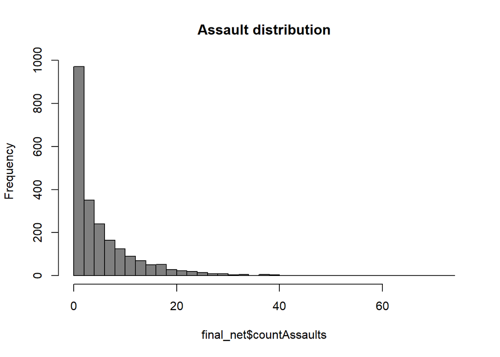

```r
hist(final_net$countAssaults,main="Assault distribution",breaks=50,col = c("grey50"))
```

## Cross-Validated

Leave One Group Out CV on spatial features while predicting crime the model. Two different lists of variables were created, one has Just risk factors and the other includes the risk factors with the Local Moran’s I Spatial Process.

```r
# View(crossValidate)

## define the variables we want

reg.vars <- c("Abandoned_Buildings.nn", "Abandoned_Cars.nn", "Graffiti.nn", "grocery.nn",
              "Liquor_Retail.nn", "restaurant.nn", "Street_Lights_Out.nn", "Sanitation.nn", "affordableRental.nn", "loopDistance")

reg.ss.vars <- c("Abandoned_Buildings.nn", "Abandoned_Cars.nn", "Graffiti.nn", "grocery.nn",
              "Liquor_Retail.nn", "restaurant.nn", "Street_Lights_Out.nn", "Sanitation.nn", "affordableRental.nn", "loopDistance", "Assualt.isSig","Assualt.isSig.dist" )


## RUN REGRESSIONS
reg.cv <- crossValidate(
  dataset = final_net,
  id = "cvID",
  dependentVariable = "countAssaults",
  indVariables = reg.vars) %>%
    dplyr::select(cvID = cvID, countAssaults, Prediction, geometry)


reg.ss.cv <- crossValidate(
  dataset = final_net,
  id = "cvID",
  dependentVariable = "countAssaults",
  indVariables = reg.ss.vars) %>%
    dplyr::select(cvID = cvID, countAssaults, Prediction, geometry)

reg.spatialCV <- crossValidate(
  dataset = final_net,
  id = "name",
  dependentVariable = "countAssaults",
  indVariables = reg.vars) %>%
    dplyr::select(cvID = name, countAssaults, Prediction, geometry)


reg.ss.spatialCV <- crossValidate(
  dataset = final_net,
  id = "name",
  dependentVariable = "countAssaults",
  indVariables = reg.ss.vars) %>%
  dplyr::select(cvID = name,countAssaults,Prediction,geometry)
```

## Accuracy & Generalzability

All the figures and tables below show that adding spatial processes to the model helps remove the large errors in the model and the mean MAE. However, even with including the spatial process features, some spatial autocorrelation remains. Engineering more spatial process features would help improve the model and minimize errors.

```r
reg.summary <-
  rbind(
    mutate(reg.cv, Error = Prediction - countAssaults,
                             Regression = "Random k-fold CV: Just Risk Factors"),

     mutate(reg.ss.cv,        Error = Prediction - countAssaults,
                             Regression = "Random k-fold CV: Spatial Process"),

    mutate(reg.spatialCV,    Error = Prediction - countAssaults,
                             Regression = "Spatial LOGO-CV: Just Risk Factors"),

    mutate(reg.ss.spatialCV, Error = Prediction - countAssaults,
                             Regression = "Spatial LOGO-CV: Spatial Process")) %>%
    st_sf()

error_by_reg_and_fold <-
  reg.summary %>%
    group_by(Regression, cvID) %>%
    summarize(Mean_Error = mean(Prediction - countAssaults, na.rm = T),
              MAE = mean(abs(Mean_Error), na.rm = T),
              SD_MAE = mean(abs(Mean_Error), na.rm = T)) %>%
  ungroup()
```

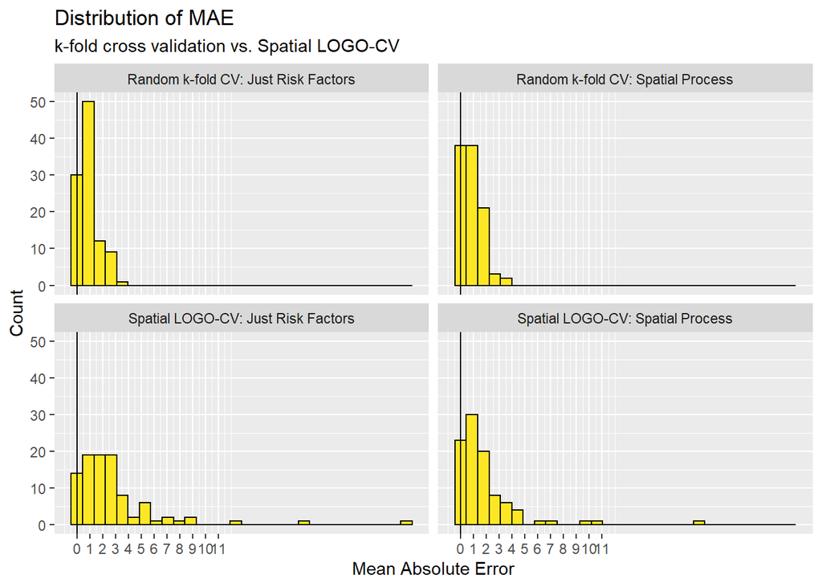

```r
## plot histogram of OOF (out of fold) errors
error_by_reg_and_fold %>%
  ggplot(aes(MAE)) +
    geom_histogram(bins = 30, colour="black", fill = "#FDE725FF") +
    facet_wrap(~Regression) +
   geom_vline(xintercept = 0) +  scale_x_continuous(breaks = seq(0, 11, by = 1)) +
    labs(title="Distribution of MAE", subtitle = "k-fold cross validation vs. Spatial LOGO-CV",
         x="Mean Absolute Error", y="Count")
```

```r
    plotTheme()
```

```r
st_drop_geometry(error_by_reg_and_fold) %>%
  group_by(Regression) %>%
    summarize(Mean_MAE = round(mean(MAE), 2),
              SD_MAE = round(sd(MAE), 2)) %>%
  kable() %>%
    kable_styling("striped", full_width = F) %>%
    row_spec(2, color = "black", background = "#FDE725FF") %>%
    row_spec(4, color = "black", background = "#FDE725FF")
```

| Regression | Mean_MAE | SD_MAE |
| --- | --- | --- |
| Random k-fold CV: Just Risk Factors | 0.96 | 0.78 |
| Random k-fold CV: Spatial Process | 0.84 | 0.71 |
| Spatial LOGO-CV: Just Risk Factors | 2.83 | 3.55 |
| Spatial LOGO-CV: Spatial Process | 1.86 | 2.53 |

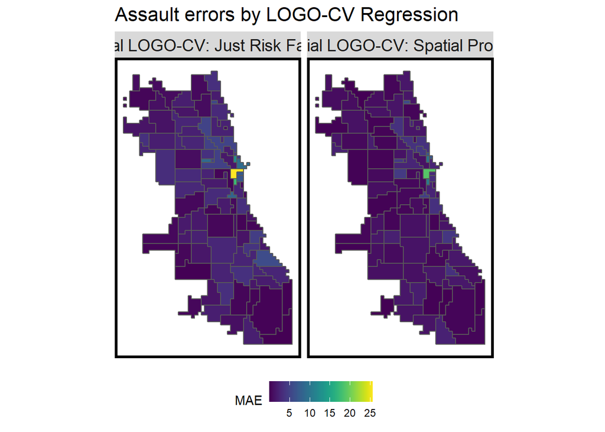

```r
error_by_reg_and_fold %>%
  filter(str_detect(Regression, "LOGO")) %>%
  ggplot() +
    geom_sf(aes(fill = MAE)) +
    facet_wrap(~Regression) +
    scale_fill_viridis() +
    labs(title = "Assault errors by LOGO-CV Regression") +
    mapTheme() + theme(legend.position="bottom")
```

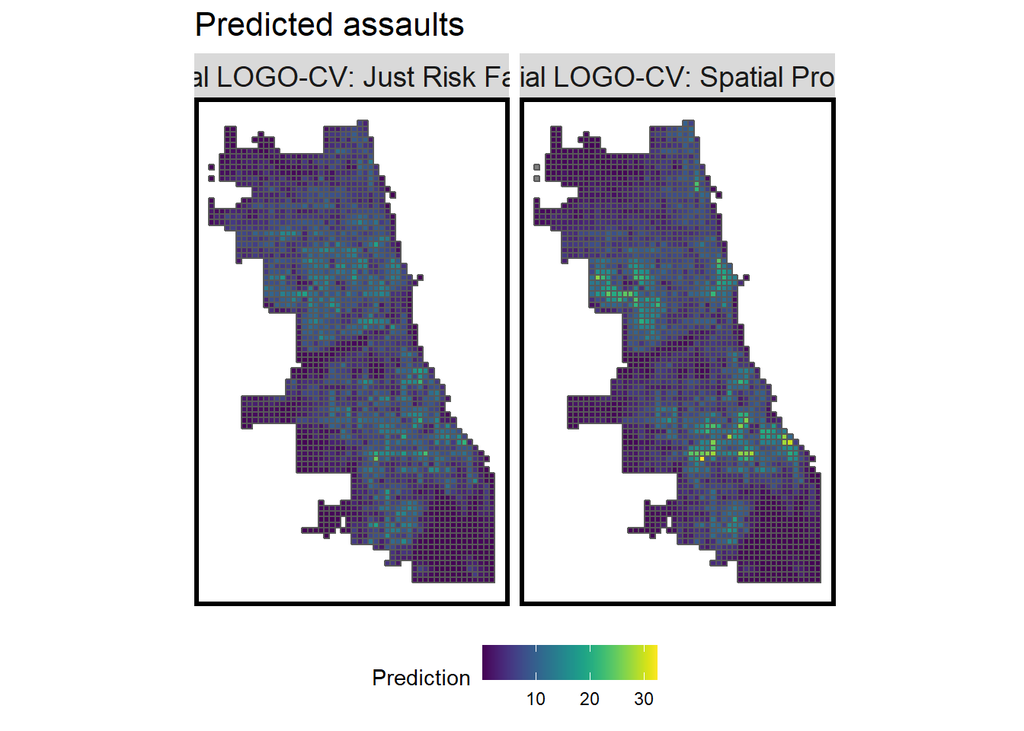

```r
predictmap<-reg.summary %>%
  group_by(Regression) %>%
    filter(str_detect(Regression, "LOGO"))
predictmap%>%
    ggplot()+
  geom_sf(aes(fill = Prediction)) +
      facet_wrap(~Regression) +
  scale_fill_viridis() +
  #xlim(0,10) +
      labs(title = "Predicted assaults")  +
    mapTheme()  + theme(legend.position="bottom")
```

## Generalizability by Race

The model under-predicts in Majority_Non_White neighborhoods and over-predicts in Majority_White neighborhoods. The Spatial Process model not only reports lower errors overall but a smaller difference in errors across neighborhood contexts.

```r
tracts18 <-
  get_acs(geography = "tract", variables = c("B01001_001E","B01001A_001E"),
          year = 2018, state=17, county=031, geometry=T) %>%
  st_transform('ESRI:102271')  %>%
  dplyr::select(variable, estimate, GEOID) %>%
  spread(variable, estimate) %>%
  rename(TotalPop = B01001_001,
         NumberWhites = B01001A_001) %>%
  mutate(percentWhite = NumberWhites / TotalPop,
         raceContext = ifelse(percentWhite > .5, "Majority_White", "Majority_Non_White")) %>%
  .[neighborhoods,]
```

```r
reg.summary %>%
    st_centroid() %>%
    st_join(tracts18) %>%
    na.omit() %>%
      st_drop_geometry() %>%
      group_by(Regression, raceContext) %>%
      summarize(mean.Error = mean(Error, na.rm = T)) %>%
      spread(raceContext, mean.Error) %>%
      kable(caption = "Mean Error by neighborhood racial context") %>%
        kable_styling("striped", full_width = F) %>%
      row_spec(2, color = "black", background = "#FDE725FF") %>%
      row_spec(4, color = "black", background = "#FDE725FF")
```

Mean Error by neighborhood racial context

| Regression | Majority_Non_White | Majority_White |
| --- | --- | --- |
| Random k-fold CV: Just Risk Factors | -0.8287572 | 0.9273991 |
| Random k-fold CV: Spatial Process | -0.2463464 | 0.2792799 |
| Spatial LOGO-CV: Just Risk Factors | -0.8792508 | 0.9494578 |
| Spatial LOGO-CV: Spatial Process | -0.2564690 | 0.2596035 |

## Density vs predictions

While the models we have created focus on predicting risk, many police departments rely on mapping density to target areas with high concentrations or hotspots of crime. This method is known as “Kernel Density” hotspot mapping.

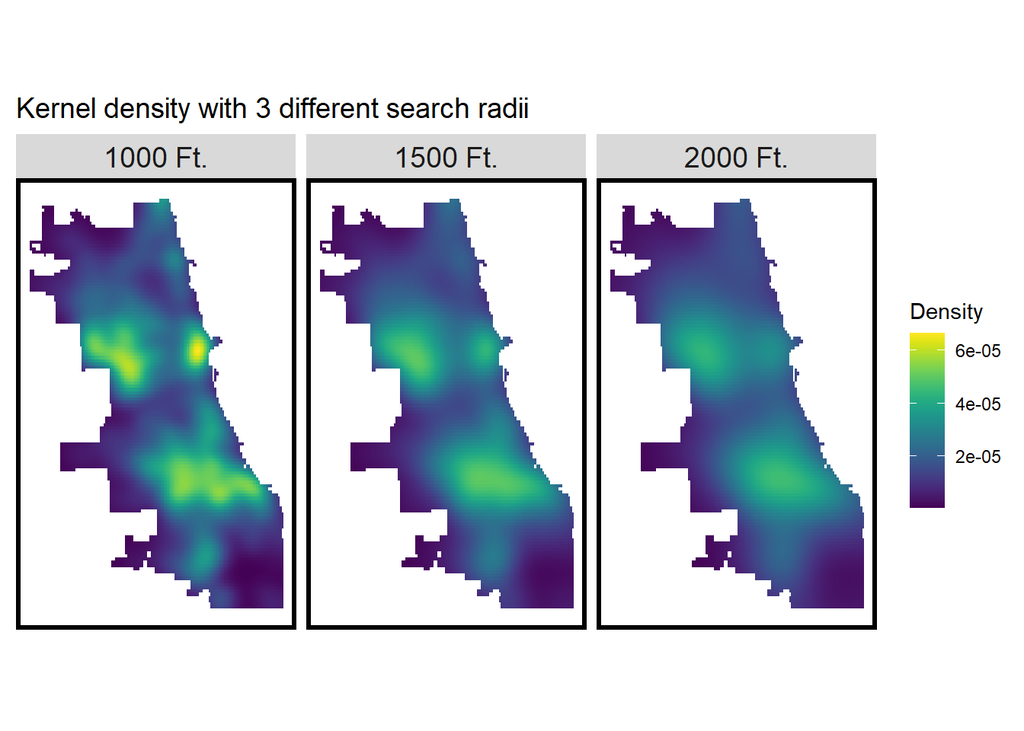

```r
# demo of kernel width
Assault_ppp <- as.ppp(st_coordinates(assault), W = st_bbox(final_net))
Assault_KD.1000 <- spatstat.core::density.ppp(Assault_ppp, 1000)
Assault_KD.1500 <- spatstat.core::density.ppp(Assault_ppp, 1500)
Assault_KD.2000 <- spatstat.core::density.ppp(Assault_ppp, 2000)
Assault_KD.df <- rbind(
  mutate(data.frame(rasterToPoints(mask(raster(Assault_KD.1000), as(neighborhoods, 'Spatial')))), Legend = "1000 Ft."),
  mutate(data.frame(rasterToPoints(mask(raster(Assault_KD.1500), as(neighborhoods, 'Spatial')))), Legend = "1500 Ft."),
  mutate(data.frame(rasterToPoints(mask(raster(Assault_KD.2000), as(neighborhoods, 'Spatial')))), Legend = "2000 Ft."))

Assault_KD.df$Legend <- factor(Assault_KD.df$Legend, levels = c("1000 Ft.", "1500 Ft.", "2000 Ft."))

ggplot(data=Assault_KD.df, aes(x=x, y=y)) +
  geom_raster(aes(fill=layer)) +
  facet_wrap(~Legend) +
  coord_sf(crs=st_crs(final_net)) +
  scale_fill_viridis(name="Density") +
  labs(title = "Kernel density with 3 different search radii") +
  mapTheme(title_size = 14)
```

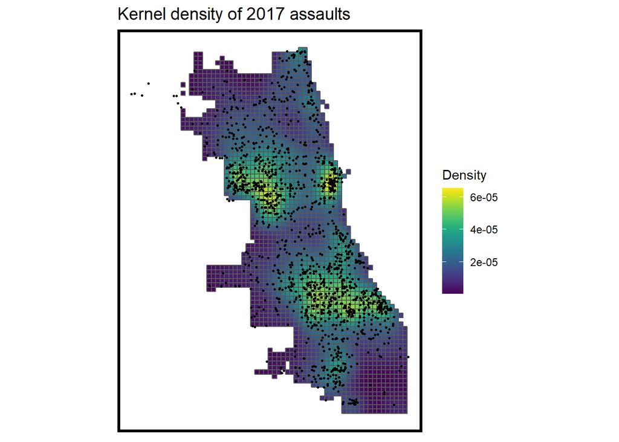

```r
as.data.frame(Assault_KD.1000) %>%
  st_as_sf(coords = c("x", "y"), crs = st_crs(final_net)) %>%
  aggregate(., final_net, mean) %>%
   ggplot() +
     geom_sf(aes(fill=value)) +
     geom_sf(data = sample_n(assault, 1500), size = .5) +
     scale_fill_viridis(name = "Density") +
     labs(title = "Kernel density of 2017 assaults") +
     mapTheme(title_size = 14)
```

```r
assault18 <-
  read.socrata("https://data.cityofchicago.org/Public-Safety/Crimes-2018/3i3m-jwuy") %>%
    filter(Primary.Type == "ASSAULT" & Description == "SIMPLE") %>%
  mutate(x = gsub("[()]", "", Location)) %>%
  separate(x,into= c("Y","X"), sep=",") %>%
  mutate(X = as.numeric(X),
         Y = as.numeric(Y)) %>%
  na.omit %>%
  st_as_sf(coords = c("X", "Y"), crs = 4326, agr = "constant") %>%
  st_transform('ESRI:102271') %>%
  distinct() %>%
  .[fishnet,]
```

```r
Assault_KDE_sum <- as.data.frame(Assault_KD.1000) %>%
  st_as_sf(coords = c("x", "y"), crs = st_crs(final_net)) %>%
  aggregate(., final_net, mean)
kde_breaks <- classIntervals(Assault_KDE_sum$value,
                             n = 5, "fisher")
Assault_KDE_sf <- Assault_KDE_sum %>%
  mutate(label = "Kernel Density",
         Risk_Category = classInt::findCols(kde_breaks),
         Risk_Category = case_when(
           Risk_Category == 5 ~ "5th",
           Risk_Category == 4 ~ "4th",
           Risk_Category == 3 ~ "3rd",
           Risk_Category == 2 ~ "2nd",
           Risk_Category == 1 ~ "1st")) %>%
  cbind(
    aggregate(
      dplyr::select(assault18) %>% mutate(AssaultCount = 1), ., sum) %>%
    mutate(AssaultCount = replace_na(AssaultCount, 0))) %>%
  dplyr::select(label, Risk_Category, AssaultCount)
```

```r
ml_breaks <- classIntervals(reg.ss.spatialCV$Prediction,
                             n = 5, "fisher")
Assault_risk_sf <-
  reg.ss.spatialCV %>%
  mutate(label = "Risk Predictions",
         Risk_Category =classInt::findCols(ml_breaks),
         Risk_Category = case_when(
           Risk_Category == 5 ~ "5th",
           Risk_Category == 4 ~ "4th",
           Risk_Category == 3 ~ "3rd",
           Risk_Category == 2 ~ "2nd",
           Risk_Category == 1 ~ "1st")) %>%
  cbind(
    aggregate(
      dplyr::select(assault18) %>% mutate(AssaultCount = 1), ., sum) %>%
      mutate(AssaultCount = replace_na(AssaultCount, 0))) %>%
  dplyr::select(label,Risk_Category, AssaultCount)
```

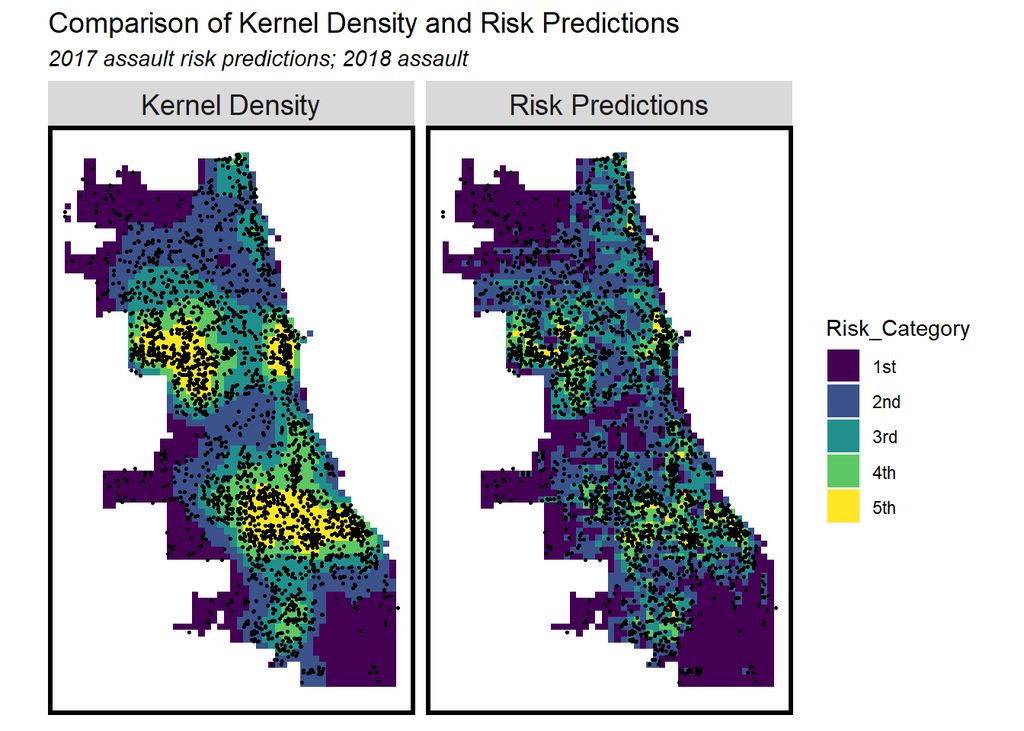

```r
rbind(Assault_KDE_sf, Assault_risk_sf) %>%
  na.omit() %>%
  gather(Variable, Value, -label, -Risk_Category, -geometry) %>%
  ggplot() +
    geom_sf(aes(fill = Risk_Category), colour = NA) +
    geom_sf(data = sample_n(assault18, 3000), size = .5, colour = "black") +
    facet_wrap(~label, ) +
    scale_fill_viridis(discrete = TRUE) +
    labs(title="Comparison of Kernel Density and Risk Predictions",
         subtitle="2017 assault risk predictions; 2018 assault") +
    mapTheme(title_size = 14)
```

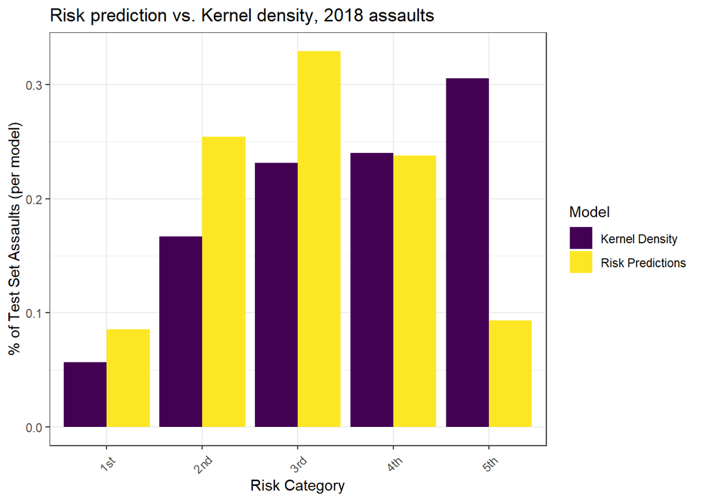

```r
rbind(Assault_KDE_sf, Assault_risk_sf) %>%
  st_drop_geometry() %>%
  na.omit() %>%
  gather(Variable, Value, -label, -Risk_Category) %>%
  group_by(label, Risk_Category) %>%
  summarize(countAssaults = sum(Value)) %>%
  ungroup() %>%
  group_by(label) %>%
  mutate(Pcnt_of_test_set_crimes = countAssaults / sum(countAssaults)) %>%
    ggplot(aes(Risk_Category,Pcnt_of_test_set_crimes)) +
      geom_bar(aes(fill=label), position="dodge", stat="identity") +
      scale_fill_viridis(discrete = TRUE, name = "Model") +
      labs(title = "Risk prediction vs. Kernel density, 2018 assaults",
           y = "% of Test Set Assaults (per model)",
           x = "Risk Category") +
  theme_bw() +
      theme(axis.text.x = element_text(angle = 45, vjust = 0.5))
```

# Conclusions

I would not recommend this algorithm be put into production. The model has a relatively high error, especially in the highest-risk category. Moreover, the model was created based on many selection biases and is not accurate enough to allocate resources and funding to prevent future crime. Instead, the model only reacts to past conditions and renders a picture of the future, assuming conditions stay constant.

As discussed in the introduction, selection bias is present in the data reporting as well as in the assumptions made when identifying risk factors. The model relies on the Broken Windows Theory to distinguish physical locations that may be more susceptible to crime. Additionally, current policing and resource planning result from systematic racism, racial discrimination, and biased judgments. These racial prejudices have driven black and brown neighborhoods to be over-policed, resulting in seemingly high crime rates in these same neighborhoods, as more police presence results in more arrests and reports. Instead of crime being equated with actual areas of high risk, crime is often equated with areas of high police presence.